# Smallmouth Bass Removal in the Green River Sub Basin

FY 2025 ANNUAL REPORT 12.9.2025

### Projects FR-115, 123a, 123b, 123d

Bureau of Reclamation Agreement Numbers and Grant Periods:

- CSU FR-115: R24AP00237
- USFWS 123a: O2501-014-014-064326
- UDWR-M 123a: R24AP00262-02
- UDWR-V 123b: R24AP00262
- UDWR-M 123d: R24AP00262-02

### Principal Investigators

- **Katherine Lawry**, U.S. Fish and Wildlife Service Green River Basin FWCO  
  Email: katherine_lawry@fws.gov
- **Christian Smith**, U.S. Fish and Wildlife Service Green River Basin FWCO  
  Email: christian_t_smith@fws.gov
- **Anna Amidon**, Utah Division of Wildlife Resources- Moab  
  Email: aamidon@utah.gov
- **Saidee J. Hyder**, Utah Division of Wildlife Resources - Vernal  
  Email: shyder@utah.gov
- **Kevin R. Bestgen**, Colorado State University Larval Fish Laboratory  
  Email: kbestgen@colostate.edu
- **Edward Kluender**, Colorado State University Larval Fish Laboratory  
  Email: edward.kluender@colostate.edu
- **Michael S. Partlow**, Utah Division of Wildlife Resources - Vernal  
  Email: mpartlow@utah.gov

# Abstract

This annual report is a comprehensive summary of all Smallmouth Bass removal conducted in the Green River in 2025. We provide a population abundance estimate for a limited segment of the Green River and comment on ages and size classes in that population. We frame the effectiveness of all electrofishing effort within the context of varying environmental conditions through space and time and explore the possibility of seasonal movement patterns. We discuss length and age structure through time and relate this to flow releases from Flaming Gorge Dam. Management recommendations are provided at the end of each section.

# Introduction

Smallmouth Bass *(Micropterus dolomieu)* became established throughout the upper Colorado River basin in the early 2000s. Reservoir escapement and several years of favorable environmental conditions facilitated the establishment of self-sustaining populations which proliferated rapidly and expanded throughout the system (Anderson 2002, 2005; Bestgen et al. 2006, Hawkins et al. 2009, Breton et al. 2013, Breton et al. 2014).

The Upper Colorado River Endangered Fish Recovery Program identified Smallmouth Bass as a threat to native fish assemblages and initiated efforts to control populations in each sub-basin. Mechanical removal (electrofishing) efforts in the Green River sub-basin began in 2003.

As of 2025, there are four ongoing electrofishing projects in the Green River sub basin. Project FR-115 is administered by Colorado State University’s Larval Fish Laboratory (CSU-LFL) and covers the Lodore and Whirlpool Canyon reaches. Project 123a is overseen by the U.S. Fish and Wildlife Service Vernal office (FWS-V) and Utah Division of Wildlife Resources – Moab (UDWR-M) and covers the Whirlpool Canyon, Island-Rainbow Park, Split Mountain Canyon, Desolation Canyon, and Gray Canyon reaches. Project 123b is managed by the Utah Division of Wildlife Resources Vernal office (UDWR-V) and covers the Jensen, Upper Middle Green, Ouray, and Lower Middle Green reaches while contributing a few days of additional bass removal in Island Park in June before the spawn. Project 123d is overseen by UDWR-M and covers the Tusher Diversion reach.

Some projects have different objectives. Project FR-115 is a long-term fish community monitoring project with an associated nonnative fish removal element. Projects 123a, 123b, and 123d are non-native fish removal projects. These projects overlap spatially and temporally in some cases. Smallmouth Bass are removed whenever they are encountered during all electrofishing projects, regardless of the project objective. We combine all four projects for calculations of Catch Per Unit Effort in this report.

This annual report provides a comprehensive summary of all Smallmouth Bass removal conducted in the Green River in 2025. We frame the effectiveness of electrofishing efforts in the context of varying environmental conditions. We offer a current quantitative snapshot of the Smallmouth Bass population size and structure in the Green River and compare this to historical trends. Management recommendations are provided at the end of each section.

This report is divided into the following five sections:

• Section 1: Smallmouth Bass Removal

• Section 2: Abundance Estimate for Dinosaur National Monument

• Section 3: Environmental Conditions

• Section 4: Seasonal Movement Patterns

• Section 5: Size Classes and Age Structure

# Section 1: Smallmouth Bass Removal

This section provides a comprehensive summary of all Smallmouth Bass removal conducted in the Green River in 2025. All tables and figures in this section show Catch Per Unit Effort (CPUE). CPUE is summarized as the number of Smallmouth Bass captured per hour of electrofishing.

CPUE measures the efficiency of electrofishing activities. A high CPUE suggests that Smallmouth Bass are easily and efficiently caught. This may suggest that a high number of Smallmouth Bass are present, or it may mean that water conditions are favorable for catching them. Likewise a low CPUE suggests that bass are harder to find and catch. This may suggest that fewer bass are present, or it may mean that water conditions are not favorable for catching bass. Catch Per Unit Effort is *not* a direct estimate of abundance. CPUE is a measure of electrofishing efficiency.

| **Project Type** | **Project Code** | **Sampling Date Range** | **Sampling River Mile Range** | **Total Effort (hr)** | **Number of Smallmouth Bass Encountered** | **CPUE (Bass/Hour)** |
| --- | --- | --- | --- | --- | --- | --- |
| Non-Native Fish Removal (electrofishing) | FR-115 123a 123b 123d | Mar 12 Sep 25 | 120 - 364 | 705.3 | 10,586 | 15.0 |

Mechanical removal effort is not evenly distributed throughout the entire Green River. It may be illustrative to examine electrofishing effort and catch rates with respect to space. Table 2 breaks down electrofishing effort and CPUE by river reach.

The most electrofishing effort was expended in Island and Rainbow Parks (116 hours), while Lodore Canyon received the least amount of electrofishing effort (24 hours; Table 2).

The highest CPUE was observed in the Lower Middle Green (23.05 bass per hour; Table 2). Lower Middle Green also had the highest CPUE in 2024 (38 fish per hour; Lawry et al 2024). The second highest CPUE was Split Mountain Canyon. The lowest CPUE was observed in the Tusher diversion reach (0.5 bass per hour; Table 2), and Lodore Canyon.  
**Table 2: Non-native fish removal electrofishing effort by reach.**

| **Reach Name** | **Sampling Date Range** | **Sampling River Mile Range** | **Total Effort (hr)** | **Number of** **Smallmouth** **Bass** **Encountered** | **CPUE** **(Bass/Hour)** |
| --- | --- | --- | --- | --- | --- |
| Lodore Canyon | Jul 21 - Sep 24 | 346.2 - 364 | 24 | 31 | 1.28 |
| Whirlpool Canyon | Jun 24 - Sep 25 | 335.5 - 346.3 | 114 | 1,803 | 15.84 |
| Island and Rainbow Parks | Jun 04 - Sep 25 | 326.7 - 344.7 | 116 | 1,931 | 16.71 |
| Split Mountain Canyon | Jun 25 - Aug 21 | 319.6 - 328.3 | 76 | 1,726 | 22.71 |
| Jensen | Apr 14 - Sep 09 | 300.8 - 321.5 | 92 | 1,375 | 14.89 |
| Upper Middle Green River | Apr 15 - Sep 10 | 260.8 - 300.8 | 87 | 1,155 | 13.29 |
| Ouray | Jul 03 - Sep 16 | 240.8 - 260.8 | 43 | 737 | 17.19 |
| Lower Middle Green River | Jun 25 - Sep 18 | 196.9 - 240.8 | 58 | 1,341 | 23.05 |
| Desolation Canyon | Jun 26 - Jun 29 | 157 - 191 | 44 | 374 | 8.52 |
| Gray Canyon | Apr 29 - Jul 01 | 128 - 151.5 | 25 | 99 | 3.98 |
| Tusher Diversion | Mar 12 - Jun 17 | 120 - 128 | 27 | 14 | 0.52 |

The Lower Middle Green reach had the highest CPUE, but ranked 6th for electrofishing effort allocation (58 hours; Table 2). UDWR-Vernal has expressed interest in adding addtional electrofishing effort here in the fall months (Saidee Hyder, personal communication).

Split Mountain Canyon had the second highest CPUE, but ranked 5th out of 11 for electrofishing effort allocation (76 hours; Table 2). Additional electrofishing effort could be added to Split Mountain Canyon by running day trips from the Rainbow Park boat ramp to the Split Mountain Boat Ramp.

A heatmap visualization of CPUE throughout the Green River bass removal area is shown in Figure 1. The reaches are designated differently in this map than they are in Table 2. On the map, the CPUE values are broken into 10-mile segments. High CPUE areas appear as bright yellow “hotspots”.

[interactive chart not shown]

**Figure 1: Smallmouth Bass CPUE map. Standard figure by C. Michaud.**

Now that we have examined Smallmouth Bass removal with respect to space, we may wish to consider CPUE with respect to time. Smallmouth Bass became established throughout the upper Colorado River basin in the early 2000s, and dedicated mechanical removal projects followed in 2003. After more than two decades of electrofishing for Smallmouth Bass, it may be useful to place this year’s CPUE values in historical context.

Historical timeseries of electrofishing CPUE for five major Green River sections are shown in figures 2a-2e. Click on each tab below to explore CPUE with respect to time for each Green River “super reach”.

Note that the following timeseries of CPUE for each river reach exclude bass <100mm in total length.

#### Catch Per Unit Effort With Respect to Time

##### Lodore

Lodore Canyon runs from Brown’s Park (RM 364) to the Yampa River confluence (RM 346.2). Smallmouth Bass CPUE in Lodore is consistently lower than the other reaches in Dinosaur National Monument, maybe due to colder water conditions that favor trout over bass.

Smallmouth Bass CPUE in Lodore Canyon is variable each year, with no distinct increase or decrease since the beginning of sampling. The 2025 value falls within the range of observations from previous years.

For a more detailed discussion of trends over time in the Lodore Reach, please see Bestgen et al (in Press).

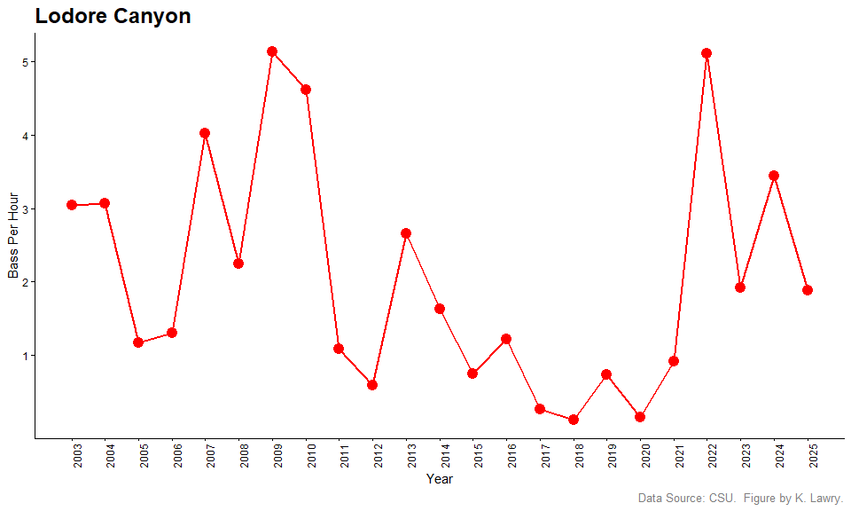

**Figure 2a: Timeseries of CPUE for Smallmouth Bass ≥ 100mm in Lodore Canyon.**

##### Echo - Split

The Echo Park - Split Mountain super reach includes everything from Echo Park (RM 344.5; just upstream of the entrance to Whirlpool Canyon) downstream to the Split Mountain boat ramp (319.6). This encompasses the Whirlpool Canyon, Island and Rainbow Parks, and Split Mountain Canyon reaches on Table 2.

Smallmouth Bass CPUE here is typically much higher than in Lodore, which is immediately upstream. This may be due to more favorable conditions, and the influence of the Yampa River tributary joining the Green River at Echo Park.

Smallmouth Bass CPUE in the Echo-Split reach is variable each year, with no distinct increase or decrease since the beginning of removal. The 2025 value falls within the range of observations from previous years.

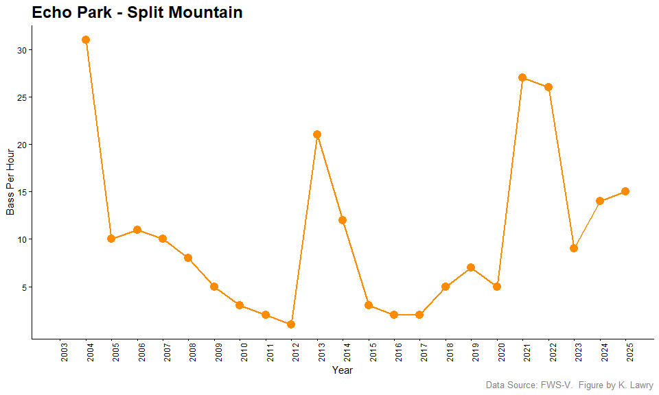

**Figure 2b: Timeseries of CPUE for Smallmouth Bass ≥ 100mm in the Echo-Split reach.**

##### Middle Green

The Middle Green tab refers to UDWR-Vernal’s project 123b reach. This super reach includes everything from Split Mountain Boat ramp (319.6) to Tabyago Riffle (206.8). This includes the Jensen, Upper Middle Green River, Ouray, and Lower Middle Green River reaches on Table 2.

Smallmouth Bass CPUE in the Middle Green is variable each year, with no distinct increase or decrease since the beginning of sampling. The 2025 value falls within the range of observations from previous years.

Higher annual CPUE values in the Middle Green have historically been attributed to removal passes in late summer or early fall. August, September and October bass removal passes tend to have higher catch rates. Older project 123b reports have shown that when removal activities in the Middle Green continue into October, bass removal numbers increase considerably (Partlow et al. 2021).

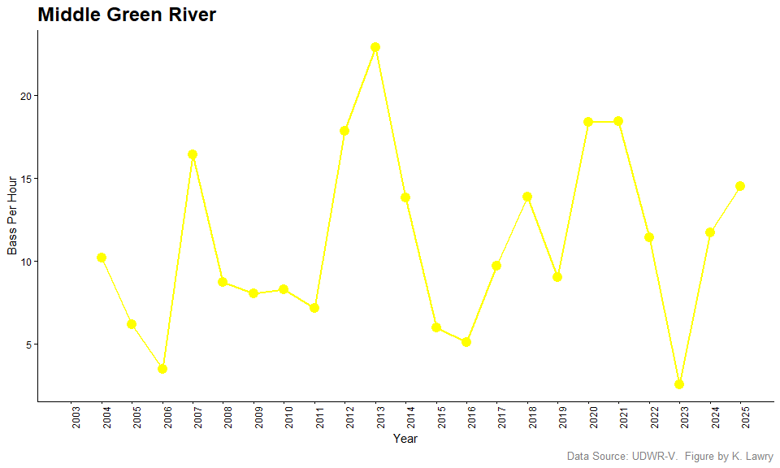

**Figure 2c: Timeseries of CPUE for Smallmouth Bass ≥ 100mm in the Middle Green reach.**

##### Desolation

The Desolation Canyon Reach runs from Tabyago Riffle (RM 207) to Joe Hutch Canyon Rapid (RM 160).

In 2025, UDWR-M completed a single smallmouth bass removal pass through Desolation and Gray Canyons, from Tabyago to Swasey’s Boat Ramp (RM 215–132). Crews conducted cataraft-mounted electrofishing along both river right and left throughout the reach. Although removal efforts were not continuous across the entire reach, as they were during Echo–Split sampling, electrofishing was dispersed and representative of the sample reach.

Starting at Tabyago Riffle (RM 207), the Green River transitions from the meandering and complex river planiform characteristic of the middle Green to the steep-gradient, channelized morphology of Desolation and Gray Canyons. Although both canyons share similar geomorphic characteristics, a limiting factor influences smallmouth bass distribution downstream into Gray Canyon from known sources of recruitment in upper reaches of the Green River. This pattern was evident during 2025 removal efforts: from Tabyago Riffle to Joe Hutch Canyon (RM 207–160), field crews conducted 37.6 hours of electrofishing and removed 438 smallmouth bass, averaging 11.7 fish per hour. In contrast, from below Joe Hutch Canyon rapid through Gray Canyon to Swasey’s Boat Ramp, crews conducted 19.5 hours of effort and removed only 90 smallmouth bass, averaging 4.6 fish per hour.

Electrofishing success is highly dependent on environmental and hydrologic variables (see Section 3); and this could in part be causing CPUE discrepancy between Desolation and Gray Canyons. Although this is a possible explanation for lowered catch rates in Gray Canyon, further investigation and analysis is warranted.

Recent attention from lower basin researchers has put a spotlight on this transition from high CPUE in Desolation Canyon tapering off significantly at Gray Canyon and downstream through the lower Green River (Pine et al. 2025). A thorough analysis of this transition reach may help identify natural limitations on bass movement and/or occupancy (e.g. turbidy or other habitat differences), providing insights to inform future management actions aimed at reducing the species’ population in the Upper Colorado River Basin.

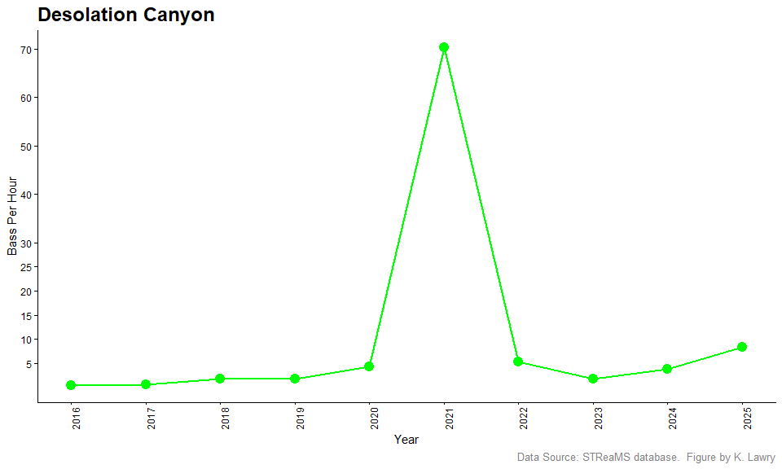

**Figure 2d: Timeseries of CPUE for Smallmouth Bass ≥ 100mm in the Desolation Canyon reach.**

Note the extremely high CPUE from 2021. This is not an error. It is the record highest CPUE obeserved anywhere in the Green River. For more information on that record-setting value, please see the Deso-Gray section of the 123a report for FY 2021 (Smith et al 2021). https://coloradoriverrecovery.org/uc/wp-content/uploads/sites/2/2022/01/123a_FY21AR_GreenRiverNNF_508.pdf

##### Gray

The Gray Canyon reach runs from just below Joe Hutch Canyon rapid (RM 160) through Gray Canyon to Swasey’s Boat Ramp (RM 132). In 2025, crews conducted 19.5 hours of effort and removed only 90 smallmouth bass, averaging 4.6 fish per hour.

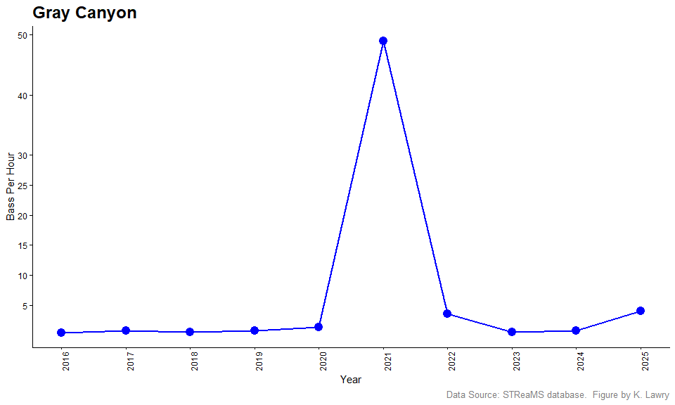

**Figure 2e: Timeseries of CPUE for Smallmouth Bass ≥ 100mm in the Gray Canyon reach.**

##### Tusher Diversion

The Tusher reach runs from RM 128 to RM 120. Smallmouth Bass CPUE in the Tusher reach remains low compared to other reaches. As mentioned in the Desolation - Gray canyon tab, it is possible that there is a barrier to movement or some other factor that limits Smallmouth Bass dispersal downstream of Desolation Canyon. Gray Canyon and the Tusher reach consistently exhibit much lower CPUE values compared to Desolation Canyon and other reaches immediately upstream.

It is also possible that the low catch rates in the Tusher reach are artifacts of flow and temperature at the time of sampling. These reaches are typically fished earlier in the season when temperatures are lower and flows are higher (See section 3 discussion on the effects of flow and temperature).

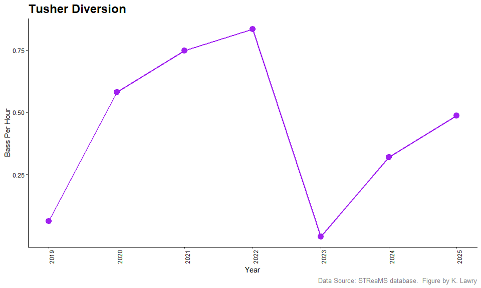

#### Limitations of CPUE

CPUE is a measure of electrofishing efficiency. Electrofishing efficiency is subject to the effects of temperature, flow, and turbidity. Environmental variables such as these may cause distortions in the relationship between CPUE and stock abundance, limiting its usefulness as an index of abundance or a measure of bass removal effectiveness.

We provide a direct estimate of abundance in Section 2, and we discuss the effects of environmental variables on CPUE in more detail in Section 3.

## Section 1 Recommendations

- Consider increasing bass removal effort in the highest CPUE reaches, especially during the spawn. FWS-V or UDWR-V could add more electrofishing effort to Split Mountain Canyon (one of the highest CPUE reaches) by running it as a day trip in addition to the multi-day passes already made by FWS-V and UDWR-M for project 123a. UDWR-V or FWS-V could consider adding more effort to the Lower Middle Green (the highest CPUE reach in 2024 and 2025) when schedules allow.
- Continue coordinating FR-115 with 123a so that electrofishing continues to the Split Mountain boat ramp, effectively combining the FR-115 July monitoring trip with a July 123a bass removal pass and population estimate recapture event.
- Increase removal effort from Tabyago Riffle through Swasey’s Boat Ramp, with specific attention to the transition from Desolation to Gray Canyons. Desolation Canyon still holds the record highest CPUE anywhere the Green River (set in 2021).

# Section 2: Abundance Estimate for Dinosaur National Monument

Catch per unit effort (CPUE) is commonly used as an index of abundance. Due to logistical constraints, CPUE is the only index of abundance in most of the Recovery Program’s Smallmouth Bass removal projects. However, using CPUE as an index of abundance can be problematic (Hilborn and Walters 1992, Maunder et al. 2006). Reliability of CPUE as an index of abundance requires the assumption that the fraction of the total fish stock caught per unit effort is relatively constant through time (Hangsleben et al. 2013). Variability in the fraction of fish caught in each effort timestep hinders the accuracy of CPUE as an index of abundance. Direct estimates of abundance may therefore be more accurate than CPUE for determining the status of a population. This section details a mark-recapture abundance estimate from project 123a in the Dinosaur National Monument segment of the Green River and provides a current quantitative snapshot of the Smallmouth Bass population size within that reach.

We estimated abundance of Smallmouth Bass in Dinosaur National Monument using a closed-population two-sample Lincoln-Petersen capture-recapture model with Chapman’s correction (Chapman 1951). Although other estimation methods are available, we sought to replicate the analysis used in previous project 123a reports for ease of comparison through time (Badame et al. 2007; Badame and Jones 2008; Badame and Jones 2009; Breidinger et al. 2010; Badame et al. 2011; Jones and Howard 2012; Jones and Howard 2013; Jones et al. 2014; Jones et al. 2015; Jones et al. 2016; Jones and Caldwell 2017; Jones and Caldwell 2018; Smith et al. 2019; Smith et al. 2020; Smith et al. 2021, Lawry et al. 2022, Lawry et al. 2023). This is also true for the choice of the model used to generate the abundance estimate, the variance approximation used to calculate confidence intervals for that estimate, and the decision to include only a subset of all observed recaptures in the abundance estimation procedure.

For those who wish to reproduce our results, the equation for the closed-population two-sample Lincoln-Petersen capture-recapture model with Chapman’s correction is given by:

$$\hat{N} = \frac{(M + 1)(C + 1)}{R + 1} - 1$$

Where:

- $\hat{N}$ is the point estimate of the total population size.
- $M$ is the number of bass marked in the initial tagging pass.
- $C$ is the number of bass captured in the subsequent removal passes.
- $R$ is the number of marked bass recaptured in the subsequent removal passes.

U.S. Fish and Wildlife Service Vernal (USFWS-V) completed one tagging pass in Dinosaur National Monument from the Echo Park boat ramp to the Split Mountain boat ramp. This area is a bass hotspot that includes project 123a river reaches Whirlpool Canyon, Island and Rainbow Parks, and Split Mountain Canyon. We tagged 199 bass ≥ 100mm using green Floy tags from June 24 - June 26, 2025.

We recaptured 42 of the 199 green-tagged bass (21%) in all subsequent removal passes (combined effort by FWS-V, UDWR-M, and CSU-LFL). We also recaptured 13 bass that were tagged and released in previous years (9 bass with yellow tags marked and released in 2024, 3 bass with white tags marked and released in 2022, and 1 bass with a pink tag marked and released in 2023).

Abundance estimates used in prior annual reports for Project 123a excluded all recaptured individuals observed during electrofishing passes that occurred more than one month after the initial marking pass. Previous practitioners of the 123a abundance estimate (2007 – 2020) reasoned that additional elapsed time between the marking event and the observation of recaptures would contribute to violations of the assumption of demographic closure implicit in the Petersen method. We followed this convention. However, beginning in 2021, we increased the number of removal passes completed within the one-month recapture timeframe and decreased the elapsed time between the marking passes and the removal passes. This strategy increased the recapture rate, which in turn has increased the precision of the estimate. We continued this practice in 2025.

We completed 11 removal passes in 2025, 7 of which fell within the month following the initial marking pass. We coordinated electrofishing schedules among UDWR-M, USFWS-V, and CSU crews to maximize removal effort in the month following the marking pass. River mile 336.6 to 333 (just above Greasy Pliers Rapid to the old Ruple Ranch boat ramp) was not electrofished during the marking pass due to an emergency evacuation of a crewmember. We excluded all fish (472 captures and 2 recaptures) encountered in this area from the abundance estimate.

We recaptured 42 Smallmouth Bass with green Floy tags (21%); however, we included only 26 recaptures in the analysis – those from removal passes completed prior to July 29th, and those captured in areas outside of RM 336.6 - 333.0. Fourteen recaptured bass from later passes (July 29th and after) and 2 from the excluded 3.6 mile reach were excluded from the analysis. The 13 recaptures that were tagged in previous years were treated as captures (as opposed to recaptures) if they fell within the appropriate timeframe, otherwise they were excluded. All bass <100mm were excluded, because only fish greater than or equal to 100mm in length were tagged. (The estimate is only pertinent to bass ≥ 100mm.)

For those who wish to reproduce our point estimate of abundance, simply substitute the appropriate values as follows:

- $M$ = 199 bass marked in the initial tagging pass.
- $C$ = 2020 bass >100mm captured in 1 month following the tagging pass.
- $R$ = 26 marked bass recaptured in 1 month following the tagging pass.

We estimated the total population of bass ≥100mm in the Echo Park to Split Mountain reach to be 14,970 bass (95% CI 9530 , 20591), or between roughly 447 and 966 bass ≥100mm per river mile. The 2025 estimate is indistinguishable from the estimate for 2024, as the confidence intervals overlap (Figure 3).

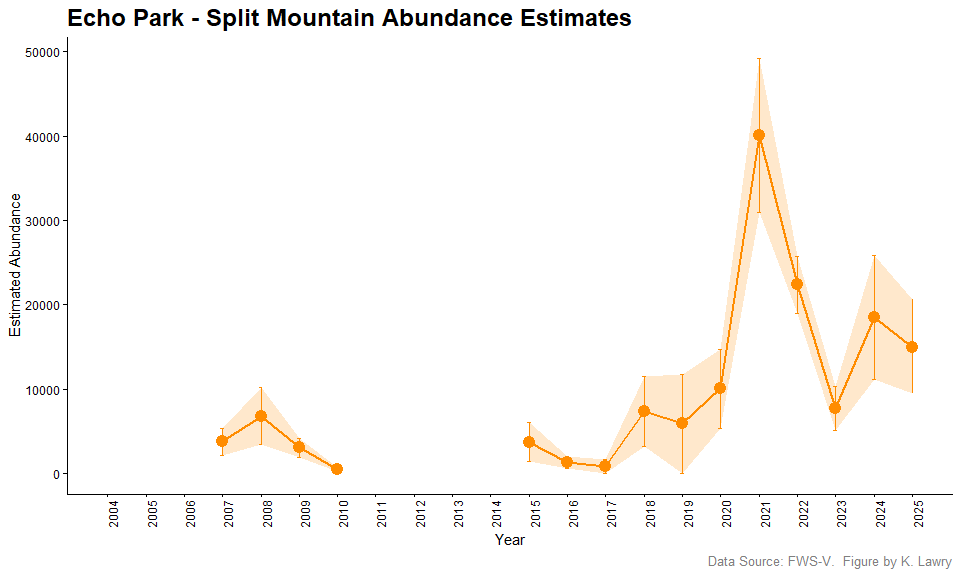

**Figure 3: Abundance estimates with 95% confidence intervals for Smallmouth Bass ≥ 100mm in the Echo-Split reach, 2007-2025.**

Confidence intervals were calculated using an informal variance approximation that was used in previous versions of the 123a report from 2007 to 2010 and 2015 to 2024 (Badame et al. 2007; Badame and Jones 2008; Badame and Jones 2009; Breidinger et al. 2010; Jones et al. 2015; Jones et al. 2016; Jones and Caldwell 2017; Jones and Caldwell 2018; Smith et al. 2019; Smith et al. 2020; Smith et al. 2021; Lawry et al. 2022; Lawry et al. 2023; Lawry et al. 2024). The confidence intervals on the 2025 abundance estimate overlap with the last three years (2022, 2023, and 2024). The coefficient of variation on the 2025 abundance estimate was 18.7%.

## Section 2 Recommendations

- Continue the mark – recapture abundance estimate in Dinosaur National Monument. Direct estimates of abundance are more accurate than CPUE for determining the status of a population.
- Coordinate projects FR-115 and 123a to continue electrofishing from Cove to Split Mountain boat ramp during the July FR-115 pass again if logistically feasible. This strategy worked well in July 2024 and 2025.
- Continue coordinating schedules between FWS-V, UDWR-M, and CSU-LFL to maximize the number of recapture passes conducted < 1 month after the marking pass; this increases recapture rate, decreases coefficient of variation, and reduces uncertainty in abundance estimates.

# Section 3: Temperature and Discharge

Catch Per Unit Effort is a measure of electrofishing efficiency. Electrofishing efficiency is not just influenced by the spatial patterns and occurrence of Smallmouth Bass (if this were true, then CPUE would be a better index of abundance). Electrofishing efficiency is also heavily influenced by the effects of temperature, flow, and turbidity.

Environmental conditions alone are known to influence electrofishing capture probability (Lyon et al 2014). Environmental variables such temperature, flow, and turbidity may cause distortions in the relationship between CPUE and stock abundance, limiting its usefulness as an index of abundance or a measure of bass removal effectiveness over time. Standardizing CPUE with generalized linear models is a common way to remove extraneous effects, resulting in an index that is more representative (Maunder and Punt 2004, Venables and Dichmont 2004, Bentley et al. 2012).

Fluctuations in discharge and thermal conditions also influence the spatial abundance and distribution of Smallmouth Bass in river systems (Graham and Orth 1986, Munther 1970; Langhurst and Schoenike 1990, McClure 2018, McClure et al 2019), which in turn may influence electrofishing catchability. Environmental conditions are known to influence bass removal efforts in the Green River; a detailed quantitative assessment of the relationship between CPUE, water temperature, and discharge was provided in section 3 of the 2023 Green River bass removal report (Lawry et al 2023). We discuss CPUE patterns with respect to environmental conditions more simplistically here.

Water temperature regulates spawning activity, and it is the driver behind basic physiological and metabolic functions. The optimal thermal range for Smallmouth Bass metabolism and growth is 18-24 °C (Coble 1967, Whitledge et al 2002, Headrick 2012). Feeding activity tends to peak in this temperature range, causing bass to aggregate in shallow, rocky shorelines where prey is most plentiful. This makes Smallmouth Bass particularly susceptible to shoreline electrofishing when water temperatures are warm.

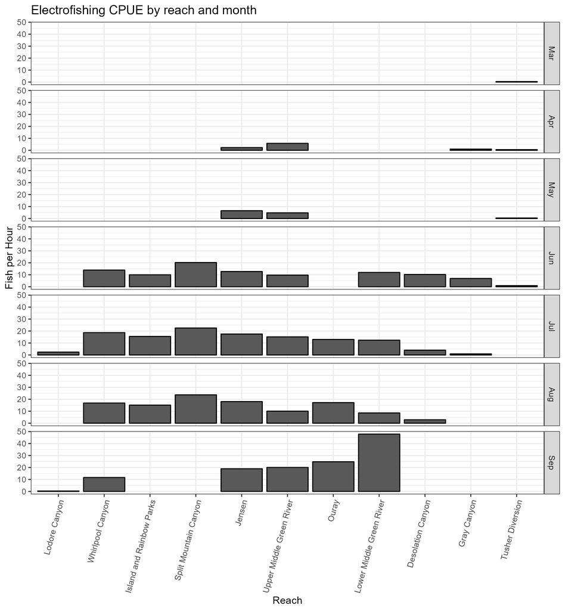

**Figure 4: Electrofishing CPUE by reach and month. Standard figure by C. Michaud**

Discharge is known to influence electrofishing efficiency. This is especially true in lowland river systems where increased discharge is accompanied by increased turbidity (Lyon et al 2014). Smallmouth Bass CPUE in the Green River has a statistically significant inverse linear relationship with discharge (Lawry et al 2023). As discharge decreases, bass CPUE generally increases.

The hydrologic conditions observed in 2025 fell below the 25-year median (Figure 5). Most bass removal effort occurred either during the descending limb of the hydrograph or during baseflow conditions (Figure 5).

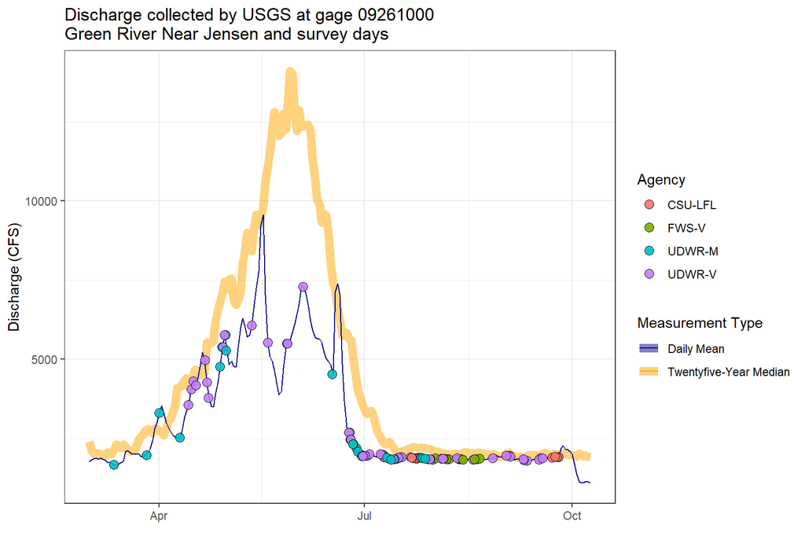

**Figure 5: Electrofishing events with respect to discharge. Standard figure by C. Michaud**

The Middle Green River may be a simple case study for environmental conditions. Higher annual CPUE values in the Middle Green have historically been attributed to removal passes in late summer or early fall. Historically, August, September and October bass removal passes tend to have higher catch rates than removal passes earlier in the year. Recall from Section 1 that the Lower Middle Green had the highest CPUE among all reaches; this was also true in 2024 (Lawry et al. 2024). The combination of low flows and warm water temperatures during the late summer and early fall timing of these passes may have contributed to high CPUE values for this reach (compared with other reaches such as Jensen and the Upper Middle Green where removal started in April; Table 2).

It may not be all about flow and temperature though. It is also possible that there is an underlying seasonal movement pattern that drives the spatial distribution of Smallmouth Bass in the system such that an aggregate of individuals occurs in the Middle Green in the fall, causing a CPUE spike associated with later passes. Older project 123b reports have shown that when removal activities in the Middle Green continue into October, CPUE values increase considerably, in some years going from 12 bass/hour in September to over 30 bass/hour in October (Partlow et al. 2021). We discuss the possibility of seasonal movement patterns in more detail in Section 4.

## Section 3 recommendations

- Turbidity data are associated with most electrofishing data collected by the Recovery Program. Analyze CPUE data with resptect to Turbidity data to determine the relationship between CPUE and turbidity in the Green River.
- Consider standardizing comparisons of CPUE throughout all Recovery Program bass removal reaches (Green River and elsewhere) to account for the effects of temperature, flow, and turbidity.
- Continue bass removal in the Middle Green into early fall months when logistically feasible.

# Section 4: Seasonal Movement Patterns

Smallmouth Bass are known to move seasonally in river systems. Seasonal movement patterns are well documented and tend to be system-specific (Larimore 1952; Fajen 1962; Munther 1970; Todd and Rabeni 1989; Langhurst and Schoenike 1990; Gunderson VanArnum et al. 2004; Rubenson and Olden 2016, McClure 2018, McClure et al 2019). Some studies have reported relatively small-scale movement restricted to areas less than 3 river miles (Larimore 1952; Fajen 1962). Other studies have reported larger-scale movement patterns between 20 and 100 river miles (Munther 1970, Todd and Rabeni 1989; Langhurst and Schoenike 1990, Rubenson and Olden 2016, McClure 2018, McClure et al. 2019). Seasonal movements result in changes to the spatial abundance and distribution of fish (Fajen 1962; Munther 1970; Montgomery et al. 1980; Todd and Rabeni 1989; Langhurst and Schoenike 1990; Gunderson VanArnum et al. 2004, Rebenson and Olden 2016, McClure 2018, McClure et al. 2019). Seasonal changes in spatial abundance and distribution of fish may impact success of electrofishing efforts and should be considered when planning new efforts or evaluating previous efforts.

Seasonal movement patterns for Smallmouth Bass in other systems tend to be centered around major life history events (e.g., spawning activity; Gunderson Van Arnum et al. 2004, McClure 2018, McClure et al. 2019) and in response to seasonally changing thermal conditions (Munther 1970; Langhurst and Schoenike 1990, McClure 2018, McClure et al 2019). Changing thermal conditions are the cue for spawning activity. Smallmouth Bass in other western river systems, such as the Snake River, have been observed running upstream during the early summer months to spawn and returning to downstream reaches later in the season to feed aggressively and prepare for winter (McClure 2018, McClure et al 2019). This may be true in the Green River system as well.

Smallmouth Bass may be running upstream during the early summer months to spawn in favorable habitat in Dinosaur National Monument and in tributaries such as the Yampa River, Duchesne River, White River. Floy tagged bass from the Echo Park - Split Mountain mark-recapture project are regularly encountered the following year during spring removal passes upstream in Yampa Canyon. Smallmouth Bass may then be returning to downstream reaches such as the Middle Green later in the season. Older project 123b reports have shown that when removal activities in the Middle Green continue into October, bass removal numbers increase considerably, in some years going from 12 bass/hour in September to over 30 bass/hour in October (Partlow et al. 2021). A pattern such as this would be consistent with seasonal Smallmouth Bass movement patterns that have been observed in other Western systems.